# Project 2A: Galton Data

Ben Whitehead

Thursday, December 02, 2021 @ 12:10 PM

## Setup

### Packages Used

```r
library(tidyverse)
library(expss)
```

### Datasets Used

```r
galtonfamiliesmain <- read_csv("https://raw.githubusercontent.com/STAT-JET-ASU/Datasets/master/Instructor/galtonfamiliesmain.csv")
glimpse(galtonfamiliesmain)
```

```
Rows: 898
Columns: 6
$ FamilyID <chr> "1", "1", "1", "1", "2", "2", "2", "2", "3", "3", "4", "4", "…
$ Children <dbl> 4, 4, 4, 4, 4, 4, 4, 4, 2, 2, 5, 5, 5, 5, 5, 6, 6, 6, 6, 6, 6…
$ Father   <dbl> 78.5, 78.5, 78.5, 78.5, 75.5, 75.5, 75.5, 75.5, 75.0, 75.0, 7…
$ Mother   <dbl> 67.0, 67.0, 67.0, 67.0, 66.5, 66.5, 66.5, 66.5, 64.0, 64.0, 6…
$ Child    <chr> "Son", "Daughter", "Daughter", "Daughter", "Son", "Son", "Dau…
$ Height   <dbl> 73.2, 69.2, 69.0, 69.0, 73.5, 72.5, 65.5, 65.5, 71.0, 68.0, 7…
```

```r
galtonfamiliessub <- read_csv("https://raw.githubusercontent.com/STAT-JET-ASU/Datasets/master/Instructor/galtonfamiliessub.csv")
glimpse(galtonfamiliessub)
```

```
Rows: 36
Columns: 6
$ FamilyID <dbl> 13, 13, 50, 50, 84, 84, 84, 84, 84, 111, 120, 120, 120, 120, …
$ Children <dbl> 2, 2, 2, 2, 4, 4, 4, 4, 4, 1, 11, 11, 11, 11, 11, 11, 11, 11,…
$ FatherR  <dbl> 13.0, 13.0, 11.0, 11.0, 10.5, 10.5, 10.5, 10.5, 10.5, 9.0, 9.…
$ MotherR  <dbl> 7.0, 7.0, 5.4, 5.4, 3.0, 3.0, 3.0, 3.0, 3.0, 3.5, 2.0, 2.0, 2…
$ Child    <chr> "Son", "Daughter", "Son", "Daughter", "Son", "Son", "Son", "D…
$ HeightR  <dbl> 11.0, 2.0, 13.0, 2.0, 10.0, 8.5, 5.5, 5.5, 3.5, 5.5, 12.0, 10…
```

### Collaborators

NONE

## Visualizations

### Background of the Data

Francis Galton, a cousin of Charles Darwin, studied the relationship between parent heights and the heights of their offspring. His pioneering [1886 article](https://galton.org/essays/1880-1889/galton-1886-jaigi-regression-stature.pdf) is the first appearance of regression analysis in print. He originated many statistical terms and concepts, including regression, correlation, deviate, quartile, and percentile, plus median for the midpoint of a distribution. The `galtonheightdata` dataset was [created under the direction of Dr. James A. Hanley](http://www.medicine.mcgill.ca/epidemiology/hanley/galton/) using Galton’s [original paper notebooks](http://www.medicine.mcgill.ca/epidemiology/hanley/galton/notebook/index.html) containing the measurement data. You can access the `galtonfamiliesmain.csv` and `galtonfamiliessub.csv` datasets from their [description](https://stat-jet-asu.github.io/Datasets/InstructorDescriptions/galtonheightdata.html) page, which also contains variable definitions.

### Create Analysis Datasets

#### Dataset #1

Load the `galtonfamiliesmain.csv` and `galtonfamiliessub.csv` datasets above under the **Setup** header and use `glimpse()` to explore their structures. Use your code from Project 1 and/or draw from the Project 1 solutions to assemble a dataset below that meets the following criteria. Use `datatable()` from the DT package to display the result.

- contains these variables:
  - `familyid` = ID number of the family, with `136A` recoded as `205`
  - `num_children`= the number of children in the family
  - `father_ht` = the height of the father
  - `mother_ht` = the “transmuted” (per Galton) height of the mother
  - `midparent` = the average of the parents’ heights
  - `child_sex`= whether the child is a son or a daughter, all lower case
  - `child_ht` = the height of the child with daughter heights “transmuted”
- is arranged according to:
  - ascending order of familyid
  - sons before daughters within family
  - in order of height within each sex of child

```r
data_main <- galtonfamiliesmain %>%
  transmute(familyid = as.numeric(replace(FamilyID,
                                          FamilyID == "136A", 205)),
            num_children = Children,
            father_ht = Father,
            mother_ht = Mother * 1.08,
            midparent = (father_ht + mother_ht)/2,
            child_sex = tolower(Child),
            child_ht = ifelse(child_sex == "son",
                              Height, Height*1.08)
            )

data_sub <- galtonfamiliessub %>%
  transmute(familyid = FamilyID,
            num_children = Children,
            father_ht = FatherR + 60,
            mother_ht = (MotherR + 60) * 1.08,
            midparent = (father_ht + mother_ht)/2,
            child_sex = tolower(Child),
            child_ht = ifelse(child_sex == "son",
                              HeightR + 60,
                              (HeightR + 60)*1.08)
            )

data_full <- data_main %>%
  bind_rows(data_sub)

data_full_ordered <- data_full %>%
  arrange(familyid, desc(child_sex), desc(child_ht))

data.table(data_full_ordered)
```

```
     familyid num_children father_ht mother_ht midparent child_sex child_ht
  1:        1            4      78.5     72.36     75.43       son   73.200
  2:        1            4      78.5     72.36     75.43  daughter   74.736
  3:        1            4      78.5     72.36     75.43  daughter   74.520
  4:        1            4      78.5     72.36     75.43  daughter   74.520
  5:        2            4      75.5     71.82     73.66       son   73.500
 ---
930:      205            8      68.5     70.20     69.35       son   68.500
931:      205            8      68.5     70.20     69.35       son   67.700
932:      205            8      68.5     70.20     69.35  daughter   69.120
933:      205            8      68.5     70.20     69.35  daughter   68.580
934:      205            8      68.5     70.20     69.35  daughter   68.040
```

#### Dataset #2

Select the variables `familyid` and `num_children` and reduce the dataset so that it contains only one row per family. Again, use `datatable()` from the DT package to display the result.

```r
reduced_data <- data_full_ordered %>%
  select(familyid, num_children) %>%
  distinct()
glimpse(reduced_data)
```

```
Rows: 205
Columns: 2
$ familyid     <dbl> 1, 2, 3, 4, 5, 6, 7, 8, 9, 10, 11, 12, 13, 14, 15, 16, 17…
$ num_children <dbl> 4, 4, 2, 5, 6, 1, 6, 3, 1, 1, 8, 1, 2, 2, 3, 9, 6, 3, 1, …
```

### Part 1: Parent/Child Heights

#### Galton’s Visualization

In his original paper (linked above), Galton created several tables and diagrams. His “Diagram Based on Table 1” of them is similar in concept to a scatterplot. Rather than dots, he grouped/tabulated the data, and then used the count of how many people were grouped at the coordinate pairs in his grid, with child as the x-axis and mid-parent as the y-axis. There are two scales: inches and deviations from 68.25 inches.

#### Updated Scatterplot #1

Create a scatterplot of child height (x-axis) versus mid-parent height (y-axis). Ordinarily, we might reverse the axes here because analysts would be more likely to model child height as a function of parent height, but we want to be able to compare the updated plot to Galton’s original. Make your dots larger than the default and adjust transparency (`alpha`) to correct for overplotting and help show the density of points.

Also include the following.

- use `color` in the `aes` to differentiate sons versus daughters
- use `scale_color_manual()` to choose two informative colors
- scale both axes so that there is a tick mark at every whole inch
- use `coord_fixed()` so that the axes have the same unit spacing
- add better x- and y-axis labels, including the units of measure
- add an informative title (you may optionally include a subtitle)
- add `color =` to `labs()` to set the legend title to `"gender of child"`
- use `theme_linedraw()` to add some additional plot formatting
- use `theme()` to move the legend to the bottom of the scatterplot

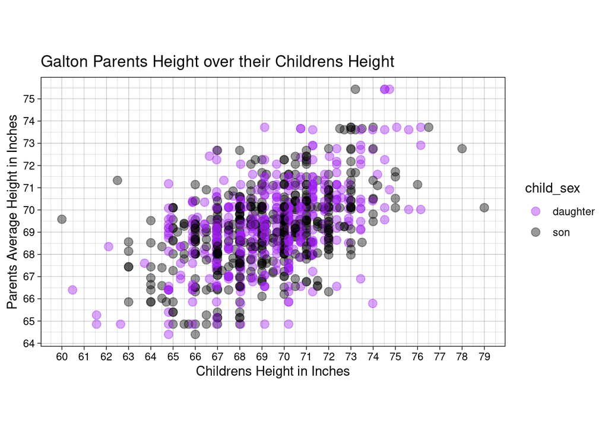

```r
ggplot(data_full_ordered, aes(x = child_ht,
                              y = midparent,
                              color = child_sex)) +
  geom_jitter(size = 3, alpha = 0.4) +
  scale_color_manual(values = c("purple", "black")) +
  scale_x_continuous(breaks = c(59:85)) +
  scale_y_continuous(breaks = c(64:76)) +
  labs(title = "Galton Parents Height over their Childrens Height",
       x = "Childrens Height in Inches",
       y = "Parents Average Height in Inches") +
  coord_fixed() +
  theme_linedraw() +
  theme()
```

#### Updated Scatterplot #2

Remove the color coding for sons versus daughters from your plot, as well as any other coding related to it. Instead, choose n single color for the points and adjust both `size` and transparency (`alpha`) as needed to correct for overplotting and help show the density of points. Reset the `aes` so child height is the `x` variable and midparent height is the `y` variable. Add a fitted *straight* line to the plot. Update your `labs` accordingly.

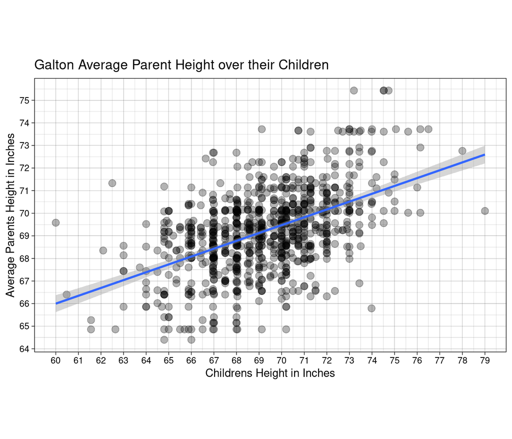

```r
ggplot(data_full_ordered, aes(x = child_ht, y = midparent)) +
  geom_jitter(size = 3, alpha = 0.3) +
  geom_smooth(method = "lm") +
  scale_x_continuous(breaks = c(59:85)) +
  scale_y_continuous(breaks = c(64:76)) +
  labs(title = "Galton Average Parent Height over their Children",
       x = "Childrens Height in Inches",
       y = "Average Parents Height in Inches") +
  coord_fixed() +
  theme_linedraw() +
  theme()
```

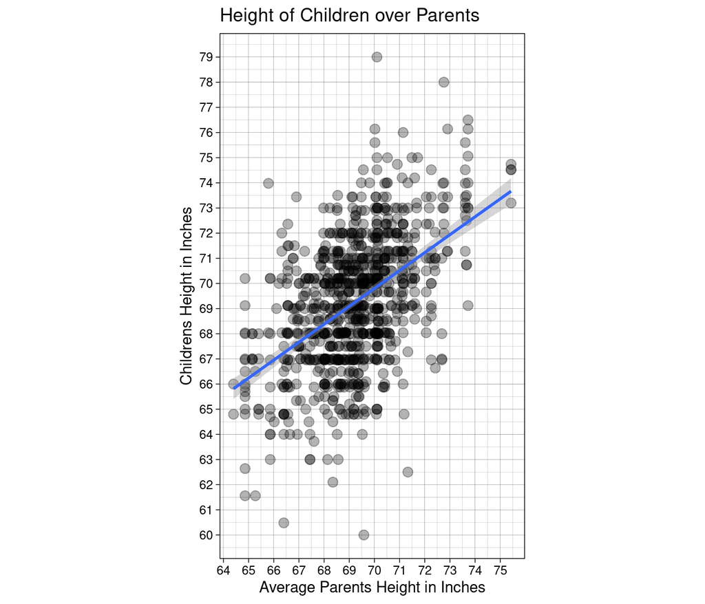

```r
ggplot(data_full_ordered, aes(y = child_ht, x = midparent)) +
  geom_jitter(size = 3, alpha = 0.3) +
  geom_smooth(method = "lm") +
  scale_x_continuous(breaks = c(64:76)) +
  scale_y_continuous(breaks = c(59:85)) +
  labs(title = "Height of Children over Parents",
       x = "Average Parents Height in Inches",
       y = "Childrens Height in Inches") +
  coord_fixed() +
  theme_linedraw() +
  theme()
```

### Part 2: Number of Children

Create a barplot to show the distribution of the number of children per family. Set the bars to something other than the default `width`. Scale the x-axis so that there is a tick mark for each bar. Choose appropriate colors, labels, themes, and/or and other types of formatting that you feel will enhance the meaning or visual appearance of the plot.

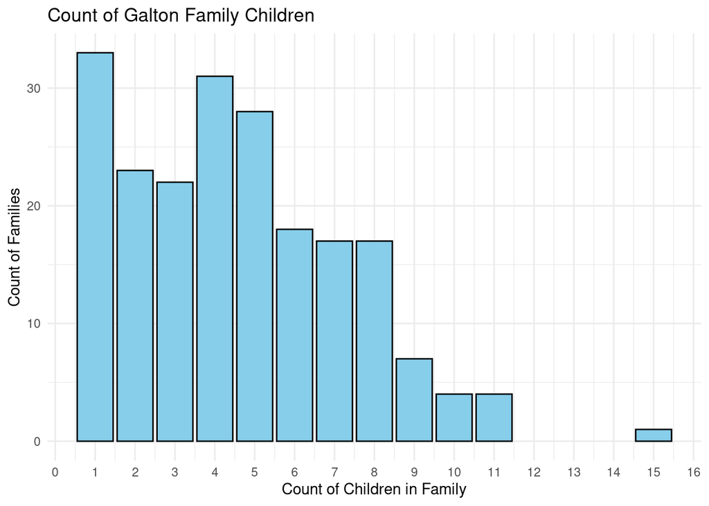

```r
ggplot(reduced_data, aes(x = num_children)) +
  geom_bar(color = "black", fill = "skyblue") +
  labs(title = "Count of Galton Family Children",
       x = "Count of Children in Family",
       y = "Count of Families") +
  scale_x_continuous(breaks = c(0:16)) +
  theme_minimal()
```

## Questions

**Question 1:** Do you think that your scatterplots are an improvement over Galton’s original diagram? Are there any modifications and/or additions you would make to enhance the clarity or usefulness of your plots?

**ANSWER**

I do believe that the scatter plots are an “improvement” over Galton’s original diagram…at least from an inexperienced Data Scientist’s mindset. I found Galton’s diagram to be too busy, especially with how many different sets of numbers are on the graph. I think that once you understood his diagram, it gave a lot more information; however, if I needed to use this within a presentation or show it to someone not in the “know”, the scatter plot does a better job. I might also add faceting to these graphs to compare the slope of the three variables: Parents, Sons, Daughters.

**Question 2:** Explain the rationale behind the choices you made when creating your scatter plots and bar plot, such as size, color, transparency, or other features. What motivated your decisions?

**ANSWER**

I first looked at the scatter plot without any aesthetics changed and decided to use the jitter function. After this, I played around with colors and realized that black and something darker seemed easy to read. I adjusted size next, but found that I probably wouldn’t have changed it if it wasn’t required. I think that going too large was definitely a concern. The transparency was a trial and error method, until I liked what I saw. I used the method = “lm” within the geom_smooth() function after we discussed that it was not “straight”. For the bar plot, I have liked the sky blue bar plots and I like the well defined edges being colored in.

**Question 3:** Considering best practices, how does using `coord_fixed()` enhance the authenticity of the information shown in the scatter plots, such as the relationship and spread of the data?

**ANSWER**

The coord_fixed() function retains the visually consistent data from the x & y axis. If you do not choose to include it, the graph scales things to “fit” the screen better, however it gives you a noticeably different slope that can make you think that there is more or less of a correlation between the data. The resizing can also make you perceive that the data is more or less grouped or spread than it really is.